# BMW Dataset

## 1. Project Planning

#### 1.1 Problem Defination

The goal of this project is to analyze Car prices and understand what factors affect the price of a car. For Example, we will check if the model, year, mileage,fuel type, or engine size has an impact on the price. This can help buyers or sellers estimate a fair price for used cars.

#### 1.2 Business Objectives

- To find which features (like mileage,engine size , or year) have the strongest effect on car price.
- To Understand how fuel type or transmission affects pricing
- To build a simple model that can predict the price of a car based on its details.

#### 1.3 Project Scope

- Dataset: Used BMW Car Dataset
- Tools: Python, Jupyter Notebook , Power BI
- Libraries: pandas , numpy, matplotlib , seaborn (for analysis and visualization)
- Timeline:
  - Data understanding and cleaning
  - Exploratory Data Analysis(EDA)
  - Visualization and Insights
- Expected Output: Cleaned data,meaningful charts , and a short summary of findings

## 2. Data Collection

#### 2.1 Identifying Data Source

The Data is already available and contains information about the used Cars. The data includes:

- Model Name
- Year of Manufacturing
- Price
- Transmission Type
- Mileage
- Fuel Type
- Tax,mpg(miles per gallon)
- Engine Size

#### 2.2 Data Gathering Techniques

The dataset will be loaded here (Jupyter Notebook)

- Data import/export

```python
import pandas as pd
import numpy as np
import matplotlib.pyplot as plt
import seaborn as sns
```

```python
df = pd.read_csv("bmw.csv")
```

```python
df
```

|  | model | year | price | transmission | mileage | fuelType | tax | mpg | engineSize |
| --- | --- | --- | --- | --- | --- | --- | --- | --- | --- |
| 0 | 5 Series | 2014 | 11200 | Automatic | 67068 | Diesel | 125 | 57.6 | 2.0 |
| 1 | 6 Series | 2018 | 27000 | Automatic | 14827 | Petrol | 145 | 42.8 | 2.0 |
| 2 | 5 Series | 2016 | 16000 | Automatic | 62794 | Diesel | 160 | 51.4 | 3.0 |
| 3 | 1 Series | 2017 | 12750 | Automatic | 26676 | Diesel | 145 | 72.4 | 1.5 |
| 4 | 7 Series | 2014 | 14500 | Automatic | 39554 | Diesel | 160 | 50.4 | 3.0 |
| ... | ... | ... | ... | ... | ... | ... | ... | ... | ... |
| 10776 | X3 | 2016 | 19000 | Automatic | 40818 | Diesel | 150 | 54.3 | 2.0 |
| 10777 | 5 Series | 2016 | 14600 | Automatic | 42947 | Diesel | 125 | 60.1 | 2.0 |
| 10778 | 3 Series | 2017 | 13100 | Manual | 25468 | Petrol | 200 | 42.8 | 2.0 |
| 10779 | 1 Series | 2014 | 9930 | Automatic | 45000 | Diesel | 30 | 64.2 | 2.0 |
| 10780 | X1 | 2017 | 15981 | Automatic | 59432 | Diesel | 125 | 57.6 | 2.0 |

10781 rows × 9 columns

#### 2.3 Data Documentation

##### Metadata

- Dataset Name : BMW Car Dataset
- Source: Given
- Number of Rows: 10,781
- Number of Columns: 9
- File Type: CSV file(.csv)
- Created for: Car price analysis and prediction
- Description: Contains details of used cars such as model, year,mileage,engine,size,fuel type, and price

##### Data Dictionary

[output not shown]

[output not shown]

##### Data Storage

The dataset is stored as a CSV file. It is Saved in my local System and loaded into Jupyter Notebook using pandas library.

- Storage Location: Local Folder( Where jupyter Notebook file is Saved)
- Access Method : Read and write Operations through pandas (read_csv() and to.csv())
- Backup: Can keep a copy of the csv file in a cloud drive(e.g Google Drive ) for Safety.

## 3. Data Preprocessing

#### 3.1 Data Cleaning

```python
df.isnull().mean()
```

```
model           0.0
year            0.0
price           0.0
transmission    0.0
mileage         0.0
fuelType        0.0
tax             0.0
mpg             0.0
engineSize      0.0
dtype: float64
```

After Checking the null values from the datset it is Observed that there is no null values in the dataset.

#### Removing Duplicates

```python
df.drop_duplicates(inplace = True)
```

Checked all the columns and rows and no duplicates found

```python
# checking datatypes
```

```python
df.dtypes
```

```
model            object
year              int64
price             int64
transmission     object
mileage           int64
fuelType         object
tax               int64
mpg             float64
engineSize      float64
dtype: object
```

#### Dealing with Outliers

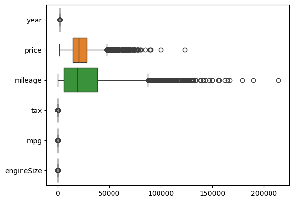

```python
sns.boxplot(df,orient = 'h')
```

```python
df1 = df.copy()
```

```python
# removing outliars
```

```python
# removing outliars using normal function
```

```python
def remove_outliers(df):
    #df = df[
        #(df['year'] >= 2012) & (df['year'] <= 2019) &
        #(df['price'] >= 4000) & (df['price'] <= 35000) &
        #(df['mileage'] >= 5000) & (df['mileage'] <= 70000) &
        #(df['tax'] >= 20) & (df['tax'] <= 180) &
        #(df['mpg'] >= 30) & (df['mpg'] <= 50) &
        #(df['engineSize'] >= 1.0 )& (df['engineSize'] <= 2.5)
   # ]
    for col in['year','price','mileage','tax','mpg','engineSize']:
            lower_q = 0.05
            upper_q = 0.95

            if col == 'year':
                lower_q,upper_q = 0.02,0.98
            elif col == 'tax':
                lower_q,upper_q = 0.20,0.98
            elif col == 'engineSize':
                lower_q , upper_q = 0.15,0.85
            elif col == 'mpg':
                lower_q, upper_q = 0.10,0.90

            q1 = df[col].quantile(lower_q)
            q9 = df[col].quantile(upper_q)
            df = df[(df[col] >= q1) & (df[col] <= q9)]


    return df.reset_index(drop = True)

df1 = remove_outliers(df1)
```

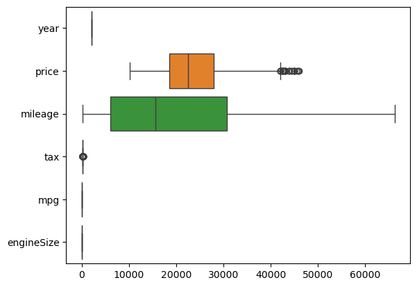

```python
sns.boxplot(df1.select_dtypes(include = 'number'), orient = 'h')
```

```python
df1.to_csv(r"C:\Users\Samruddhi\Downloads\finalData.csv")
```

#### 3.2 Data Transformation

#### Normalization

using the min-max scaling technique for data normalization

```python
from sklearn.preprocessing import MinMaxScaler
```

```python
numeric_cols = df1.select_dtypes(include = ['int64','float64']).columns
```

```python
scaler = MinMaxScaler()
```

```python
df1[numeric_cols] = scaler.fit_transform(df1[numeric_cols])
```

```python
df1[numeric_cols]
```

|  | year | price | mileage | tax | mpg | engineSize |
| --- | --- | --- | --- | --- | --- | --- |
| 0 | 0.750 | 0.470501 | 0.222620 | 0.173913 | 0.115830 | 0.0 |
| 1 | 0.500 | 0.163804 | 0.947811 | 0.304348 | 0.447876 | 1.0 |
| 2 | 0.250 | 0.121982 | 0.596456 | 0.304348 | 0.409266 | 1.0 |
| 3 | 0.500 | 0.133134 | 0.532278 | 0.000000 | 0.783784 | 0.0 |
| 4 | 0.625 | 0.163804 | 0.581096 | 0.000000 | 0.783784 | 0.0 |
| ... | ... | ... | ... | ... | ... | ... |
| 5136 | 0.375 | 0.275330 | 0.665896 | 0.652174 | 0.312741 | 1.0 |
| 5137 | 0.500 | 0.247449 | 0.615566 | 0.217391 | 0.559846 | 0.0 |
| 5138 | 0.500 | 0.124770 | 0.647753 | 0.000000 | 0.783784 | 0.0 |
| 5139 | 0.625 | 0.082948 | 0.383497 | 0.652174 | 0.115830 | 0.0 |
| 5140 | 0.625 | 0.163274 | 0.896982 | 0.000000 | 0.687259 | 0.0 |

5141 rows × 6 columns

##### Min-Max Scaling normalization scaled all numeric features of the car dataset to a uniform range between 0 to 1,ensuring balanced and comparable data for analysis

```python
# checking current working Directory
```

```python
import os
os.getcwd()
```

```
'C:\\Users\\Samruddhi\\BasicPythonProg\\BMW Project - Final'
```

```python
#Downloading Dataset into local folder
```

```python
#df_scaled.to_csv(r"C:\Users\Samruddhi\Downloads\BMW_car_data.csv" , index = False)
```

#### Encoding Categorical Variables using getdummies

```python
# checking the types of categories
df1['transmission'].unique()
```

```
array(['Automatic', 'Manual', 'Semi-Auto'], dtype=object)
```

```python
df1['fuelType'].unique()
```

```
array(['Petrol', 'Diesel', 'Hybrid'], dtype=object)
```

```python
df_dummy = pd.get_dummies(df1,columns = ['transmission'], dtype = int)
```

```python
df_dummy
```

|  | model | year | price | mileage | fuelType | tax | mpg | engineSize | transmission_Automatic | transmission_Manual | transmission_Semi-Auto |
| --- | --- | --- | --- | --- | --- | --- | --- | --- | --- | --- | --- |
| 0 | 6 Series | 0.750 | 0.470501 | 0.222620 | Petrol | 0.173913 | 0.115830 | 0.0 | 1 | 0 | 0 |
| 1 | 5 Series | 0.500 | 0.163804 | 0.947811 | Diesel | 0.304348 | 0.447876 | 1.0 | 1 | 0 | 0 |
| 2 | 7 Series | 0.250 | 0.121982 | 0.596456 | Diesel | 0.304348 | 0.409266 | 1.0 | 1 | 0 | 0 |
| 3 | 5 Series | 0.500 | 0.133134 | 0.532278 | Diesel | 0.000000 | 0.783784 | 0.0 | 1 | 0 | 0 |
| 4 | 5 Series | 0.625 | 0.163804 | 0.581096 | Diesel | 0.000000 | 0.783784 | 0.0 | 1 | 0 | 0 |
| ... | ... | ... | ... | ... | ... | ... | ... | ... | ... | ... | ... |
| 5136 | X4 | 0.375 | 0.275330 | 0.665896 | Diesel | 0.652174 | 0.312741 | 1.0 | 1 | 0 | 0 |
| 5137 | X3 | 0.500 | 0.247449 | 0.615566 | Diesel | 0.217391 | 0.559846 | 0.0 | 1 | 0 | 0 |
| 5138 | 5 Series | 0.500 | 0.124770 | 0.647753 | Diesel | 0.000000 | 0.783784 | 0.0 | 1 | 0 | 0 |
| 5139 | 3 Series | 0.625 | 0.082948 | 0.383497 | Petrol | 0.652174 | 0.115830 | 0.0 | 0 | 1 | 0 |
| 5140 | X1 | 0.625 | 0.163274 | 0.896982 | Diesel | 0.000000 | 0.687259 | 0.0 | 1 | 0 | 0 |

5141 rows × 11 columns

```python
df_dummy.shape
```

```
(5141, 11)
```

```python
df_dummy
```

|  | model | year | price | mileage | fuelType | tax | mpg | engineSize | transmission_Automatic | transmission_Manual | transmission_Semi-Auto |
| --- | --- | --- | --- | --- | --- | --- | --- | --- | --- | --- | --- |
| 0 | 6 Series | 0.750 | 0.470501 | 0.222620 | Petrol | 0.173913 | 0.115830 | 0.0 | 1 | 0 | 0 |
| 1 | 5 Series | 0.500 | 0.163804 | 0.947811 | Diesel | 0.304348 | 0.447876 | 1.0 | 1 | 0 | 0 |
| 2 | 7 Series | 0.250 | 0.121982 | 0.596456 | Diesel | 0.304348 | 0.409266 | 1.0 | 1 | 0 | 0 |
| 3 | 5 Series | 0.500 | 0.133134 | 0.532278 | Diesel | 0.000000 | 0.783784 | 0.0 | 1 | 0 | 0 |
| 4 | 5 Series | 0.625 | 0.163804 | 0.581096 | Diesel | 0.000000 | 0.783784 | 0.0 | 1 | 0 | 0 |
| ... | ... | ... | ... | ... | ... | ... | ... | ... | ... | ... | ... |
| 5136 | X4 | 0.375 | 0.275330 | 0.665896 | Diesel | 0.652174 | 0.312741 | 1.0 | 1 | 0 | 0 |
| 5137 | X3 | 0.500 | 0.247449 | 0.615566 | Diesel | 0.217391 | 0.559846 | 0.0 | 1 | 0 | 0 |
| 5138 | 5 Series | 0.500 | 0.124770 | 0.647753 | Diesel | 0.000000 | 0.783784 | 0.0 | 1 | 0 | 0 |
| 5139 | 3 Series | 0.625 | 0.082948 | 0.383497 | Petrol | 0.652174 | 0.115830 | 0.0 | 0 | 1 | 0 |
| 5140 | X1 | 0.625 | 0.163274 | 0.896982 | Diesel | 0.000000 | 0.687259 | 0.0 | 1 | 0 | 0 |

5141 rows × 11 columns

```python
df1 = df_dummy
```

```python
df1
```

|  | model | year | price | mileage | fuelType | tax | mpg | engineSize | transmission_Automatic | transmission_Manual | transmission_Semi-Auto |
| --- | --- | --- | --- | --- | --- | --- | --- | --- | --- | --- | --- |
| 0 | 6 Series | 0.750 | 0.470501 | 0.222620 | Petrol | 0.173913 | 0.115830 | 0.0 | 1 | 0 | 0 |
| 1 | 5 Series | 0.500 | 0.163804 | 0.947811 | Diesel | 0.304348 | 0.447876 | 1.0 | 1 | 0 | 0 |
| 2 | 7 Series | 0.250 | 0.121982 | 0.596456 | Diesel | 0.304348 | 0.409266 | 1.0 | 1 | 0 | 0 |
| 3 | 5 Series | 0.500 | 0.133134 | 0.532278 | Diesel | 0.000000 | 0.783784 | 0.0 | 1 | 0 | 0 |
| 4 | 5 Series | 0.625 | 0.163804 | 0.581096 | Diesel | 0.000000 | 0.783784 | 0.0 | 1 | 0 | 0 |
| ... | ... | ... | ... | ... | ... | ... | ... | ... | ... | ... | ... |
| 5136 | X4 | 0.375 | 0.275330 | 0.665896 | Diesel | 0.652174 | 0.312741 | 1.0 | 1 | 0 | 0 |
| 5137 | X3 | 0.500 | 0.247449 | 0.615566 | Diesel | 0.217391 | 0.559846 | 0.0 | 1 | 0 | 0 |
| 5138 | 5 Series | 0.500 | 0.124770 | 0.647753 | Diesel | 0.000000 | 0.783784 | 0.0 | 1 | 0 | 0 |
| 5139 | 3 Series | 0.625 | 0.082948 | 0.383497 | Petrol | 0.652174 | 0.115830 | 0.0 | 0 | 1 | 0 |
| 5140 | X1 | 0.625 | 0.163274 | 0.896982 | Diesel | 0.000000 | 0.687259 | 0.0 | 1 | 0 | 0 |

5141 rows × 11 columns

##### Hence the One Hot Encoding has been applied to the Transmission column where there are thre types

#### 3.3 Feature Engineering

#### Creating New Features

```python
# creating a Feature for Mileage per Year
```

```python
df1['car_age'] = 2025 - df1['year'] # car age created
```

```python
df1['mileage_per_year'] = df1['mileage'] / df1['car_age'] # mileage per year calculated
```

```python
df1
```

|  | model | year | price | mileage | fuelType | tax | mpg | engineSize | transmission_Automatic | transmission_Manual | transmission_Semi-Auto | car_age | mileage_per_year |
| --- | --- | --- | --- | --- | --- | --- | --- | --- | --- | --- | --- | --- | --- |
| 0 | 6 Series | 0.750 | 0.470501 | 0.222620 | Petrol | 0.173913 | 0.115830 | 0.0 | 1 | 0 | 0 | 2024.250 | 0.000110 |
| 1 | 5 Series | 0.500 | 0.163804 | 0.947811 | Diesel | 0.304348 | 0.447876 | 1.0 | 1 | 0 | 0 | 2024.500 | 0.000468 |
| 2 | 7 Series | 0.250 | 0.121982 | 0.596456 | Diesel | 0.304348 | 0.409266 | 1.0 | 1 | 0 | 0 | 2024.750 | 0.000295 |
| 3 | 5 Series | 0.500 | 0.133134 | 0.532278 | Diesel | 0.000000 | 0.783784 | 0.0 | 1 | 0 | 0 | 2024.500 | 0.000263 |
| 4 | 5 Series | 0.625 | 0.163804 | 0.581096 | Diesel | 0.000000 | 0.783784 | 0.0 | 1 | 0 | 0 | 2024.375 | 0.000287 |
| ... | ... | ... | ... | ... | ... | ... | ... | ... | ... | ... | ... | ... | ... |
| 5136 | X4 | 0.375 | 0.275330 | 0.665896 | Diesel | 0.652174 | 0.312741 | 1.0 | 1 | 0 | 0 | 2024.625 | 0.000329 |
| 5137 | X3 | 0.500 | 0.247449 | 0.615566 | Diesel | 0.217391 | 0.559846 | 0.0 | 1 | 0 | 0 | 2024.500 | 0.000304 |
| 5138 | 5 Series | 0.500 | 0.124770 | 0.647753 | Diesel | 0.000000 | 0.783784 | 0.0 | 1 | 0 | 0 | 2024.500 | 0.000320 |
| 5139 | 3 Series | 0.625 | 0.082948 | 0.383497 | Petrol | 0.652174 | 0.115830 | 0.0 | 0 | 1 | 0 | 2024.375 | 0.000189 |
| 5140 | X1 | 0.625 | 0.163274 | 0.896982 | Diesel | 0.000000 | 0.687259 | 0.0 | 1 | 0 | 0 | 2024.375 | 0.000443 |

5141 rows × 13 columns

#### Combining Features

```python
# combing engineSize and Fuel_Type
```

```python
df1['engine_fuel'] = df1['engineSize'].astype(str) + ' Lit ' + df1['fuelType']
```

```python
df1
```

|  | model | year | price | mileage | fuelType | tax | mpg | engineSize | transmission_Automatic | transmission_Manual | transmission_Semi-Auto | car_age | mileage_per_year | engine_fuel |
| --- | --- | --- | --- | --- | --- | --- | --- | --- | --- | --- | --- | --- | --- | --- |
| 0 | 6 Series | 0.750 | 0.470501 | 0.222620 | Petrol | 0.173913 | 0.115830 | 0.0 | 1 | 0 | 0 | 2024.250 | 0.000110 | 0.0 Lit Petrol |
| 1 | 5 Series | 0.500 | 0.163804 | 0.947811 | Diesel | 0.304348 | 0.447876 | 1.0 | 1 | 0 | 0 | 2024.500 | 0.000468 | 1.0 Lit Diesel |
| 2 | 7 Series | 0.250 | 0.121982 | 0.596456 | Diesel | 0.304348 | 0.409266 | 1.0 | 1 | 0 | 0 | 2024.750 | 0.000295 | 1.0 Lit Diesel |
| 3 | 5 Series | 0.500 | 0.133134 | 0.532278 | Diesel | 0.000000 | 0.783784 | 0.0 | 1 | 0 | 0 | 2024.500 | 0.000263 | 0.0 Lit Diesel |
| 4 | 5 Series | 0.625 | 0.163804 | 0.581096 | Diesel | 0.000000 | 0.783784 | 0.0 | 1 | 0 | 0 | 2024.375 | 0.000287 | 0.0 Lit Diesel |
| ... | ... | ... | ... | ... | ... | ... | ... | ... | ... | ... | ... | ... | ... | ... |
| 5136 | X4 | 0.375 | 0.275330 | 0.665896 | Diesel | 0.652174 | 0.312741 | 1.0 | 1 | 0 | 0 | 2024.625 | 0.000329 | 1.0 Lit Diesel |
| 5137 | X3 | 0.500 | 0.247449 | 0.615566 | Diesel | 0.217391 | 0.559846 | 0.0 | 1 | 0 | 0 | 2024.500 | 0.000304 | 0.0 Lit Diesel |
| 5138 | 5 Series | 0.500 | 0.124770 | 0.647753 | Diesel | 0.000000 | 0.783784 | 0.0 | 1 | 0 | 0 | 2024.500 | 0.000320 | 0.0 Lit Diesel |
| 5139 | 3 Series | 0.625 | 0.082948 | 0.383497 | Petrol | 0.652174 | 0.115830 | 0.0 | 0 | 1 | 0 | 2024.375 | 0.000189 | 0.0 Lit Petrol |
| 5140 | X1 | 0.625 | 0.163274 | 0.896982 | Diesel | 0.000000 | 0.687259 | 0.0 | 1 | 0 | 0 | 2024.375 | 0.000443 | 0.0 Lit Diesel |

5141 rows × 14 columns

##### Combined two columns named engine_Size and fuel_Type and created new feature engine_fuel

#### 3.4 Exploratory Data Analysis(EDA)

#### Summary Statistics

```python
print("Dataset Information is given below: ")
df1.info()
```

```
Dataset Information is given below:
<class 'pandas.core.frame.DataFrame'>
RangeIndex: 5141 entries, 0 to 5140
Data columns (total 14 columns):
 #   Column                  Non-Null Count  Dtype
---  ------                  --------------  -----
 0   model                   5141 non-null   object
 1   year                    5141 non-null   float64
 2   price                   5141 non-null   float64
 3   mileage                 5141 non-null   float64
 4   fuelType                5141 non-null   object
 5   tax                     5141 non-null   float64
 6   mpg                     5141 non-null   float64
 7   engineSize              5141 non-null   float64
 8   transmission_Automatic  5141 non-null   int64
 9   transmission_Manual     5141 non-null   int64
 10  transmission_Semi-Auto  5141 non-null   int64
 11  car_age                 5141 non-null   float64
 12  mileage_per_year        5141 non-null   float64
 13  engine_fuel             5141 non-null   object
dtypes: float64(8), int64(3), object(3)
memory usage: 562.4+ KB
```

```python
print("Whole Summary for the Numerical Columns is as below: ")
df1.describe()
```

```
Whole Summary for the Numerical Columns is as below:
```

|  | year | price | mileage | tax | mpg | engineSize | transmission_Automatic | transmission_Manual | transmission_Semi-Auto | car_age | mileage_per_year |
| --- | --- | --- | --- | --- | --- | --- | --- | --- | --- | --- | --- |
| count | 5141.000000 | 5141.000000 | 5141.000000 | 5141.000000 | 5141.000000 | 5141.000000 | 5141.000000 | 5141.000000 | 5141.000000 | 5141.000000 | 5141.000000 |
| mean | 0.687099 | 0.369970 | 0.301491 | 0.211987 | 0.512149 | 0.251507 | 0.346236 | 0.111262 | 0.542501 | 2024.312901 | 0.000149 |
| std | 0.211931 | 0.184220 | 0.252001 | 0.149061 | 0.276409 | 0.433922 | 0.475816 | 0.314487 | 0.498239 | 0.211931 | 0.000124 |
| min | 0.000000 | 0.000000 | 0.000000 | 0.000000 | 0.000000 | 0.000000 | 0.000000 | 0.000000 | 0.000000 | 2024.000000 | 0.000000 |
| 25% | 0.500000 | 0.233257 | 0.089169 | 0.173913 | 0.312741 | 0.000000 | 0.000000 | 0.000000 | 0.000000 | 2024.125000 | 0.000044 |
| 50% | 0.750000 | 0.344755 | 0.234383 | 0.173913 | 0.482625 | 0.000000 | 0.000000 | 0.000000 | 1.000000 | 2024.250000 | 0.000116 |
| 75% | 0.875000 | 0.495260 | 0.463519 | 0.217391 | 0.737452 | 1.000000 | 1.000000 | 0.000000 | 1.000000 | 2024.500000 | 0.000229 |
| max | 1.000000 | 1.000000 | 1.000000 | 1.000000 | 1.000000 | 1.000000 | 1.000000 | 1.000000 | 1.000000 | 2025.000000 | 0.000494 |

```python
print("Checking for the Missing Values in each Column: ")
df1.isnull().sum()
```

```
Checking for the Missing Values in each Column:
```

```
model                     0
year                      0
price                     0
mileage                   0
fuelType                  0
tax                       0
mpg                       0
engineSize                0
transmission_Automatic    0
transmission_Manual       0
transmission_Semi-Auto    0
car_age                   0
mileage_per_year          0
engine_fuel               0
dtype: int64
```

#### Visualizing Relationships

```python
# Visualizing Distribution of Numerical Feature/columns
```

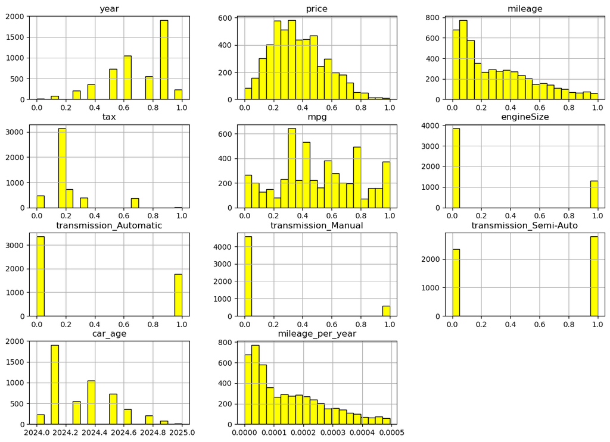

```python
df1.hist(figsize = (14,10),bins = 20,color = 'yellow',edgecolor = 'black')
plt.show()
```

```python
# boxplot to check outliars visually
```

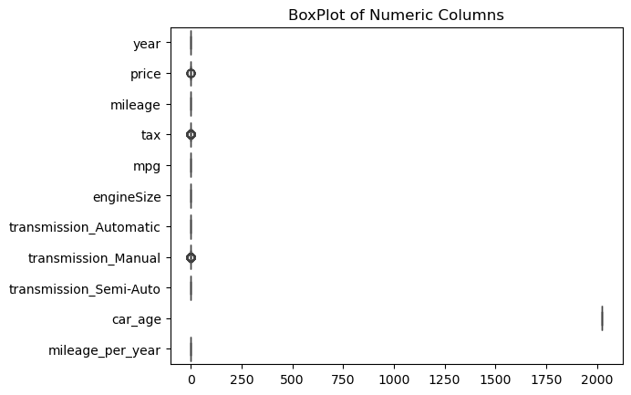

```python
plt.title('BoxPlot of Numeric Columns')
sns.boxplot(df1.select_dtypes(include = 'number') , orient = 'h')
plt.show()
```

```python
# removing outliars from mileage_per_year
Q1 = df1['price'].quantile(0.25)
```

```python
Q3 = df1['price'].quantile(0.75)
```

```python
IQR = Q3 - Q1
```

```python
# define the bounds
```

```python
lower = Q1 - 1.5 * IQR
```

```python
upper = Q3 + 1.5 * IQR
```

```python
# remove outliars
final_df = df1[(df1['price'] >= lower) & (df1['price'] <= upper)]
```

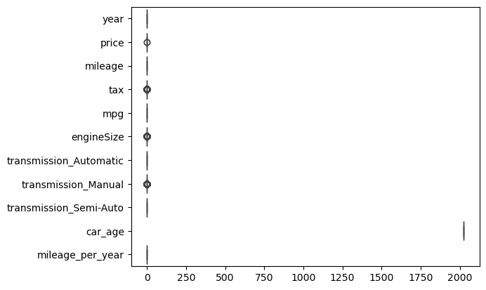

```python
sns.boxplot(final_df , orient = 'h')
```

```python
final_df.columns
```

```
Index(['model', 'year', 'price', 'mileage', 'fuelType', 'tax', 'mpg',
       'engineSize', 'transmission_Automatic', 'transmission_Manual',
       'transmission_Semi-Auto', 'car_age', 'mileage_per_year', 'engine_fuel'],
      dtype='object')
```

```python
# to remove outliars from manual
```

```python
Q1 = df1['transmission_Manual'].quantile(0.25)
```

```python
Q3 = df1['transmission_Manual'].quantile(0.75)
```

```python
IQR = Q3 - Q1
```

```python
lower = Q1 - 1.2 * IQR
```

```python
upper = Q3 + 1.2 * IQR
```

```python
final = final_df[(final_df['transmission_Manual'] >= lower) & (final_df['transmission_Manual'] <= upper)]
```

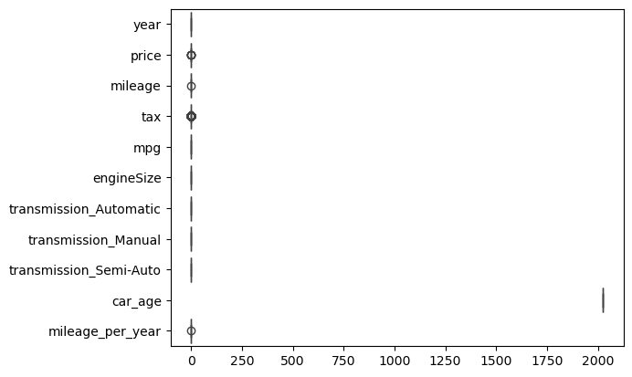

```python
sns.boxplot(final, orient = 'h')
```

##### Hence the outliar of the transmission_Manual has been removed

```python
# visualizing relationships between variables using scatterplot
```

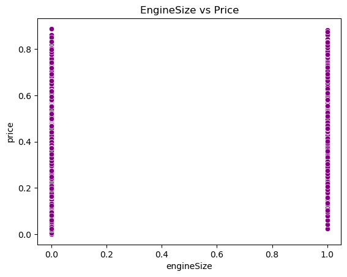

```python
#price vs EngineSize
sns.scatterplot(x ='engineSize' , y ='price' ,color = 'purple' , data = final_df)
plt.title('EngineSize vs Price')
plt.show()
```

[output not shown]